# Risk Factor Analysis

## Outcome Variable

**Outcome Variable:** stunted

## Predictor Variables

**Intervention Variable:** mage

**Adjustment Set:**

- arm
- meducyrs
- feducyrs
- W_mhtcm
- W_mwtkg
- W_mbmi
- single
- delta_meducyrs
- delta_feducyrs
- delta_W_mhtcm
- delta_W_mwtkg
- delta_W_mbmi
- delta_single

## Stratifying Variables

The analysis was stratified on these variable(s):

- agecat
- studyid
- country

## Data Summary

| agecat | studyid | country | mage | stunted | n_cell | n |
| --- | --- | --- | --- | --- | --- | --- |
| Birth | ki0047075b-MAL-ED | BANGLADESH | [20-30) | 0 | 133 | 231 |
| Birth | ki0047075b-MAL-ED | BANGLADESH | [20-30) | 1 | 27 | 231 |
| Birth | ki0047075b-MAL-ED | BANGLADESH | <20 | 0 | 22 | 231 |
| Birth | ki0047075b-MAL-ED | BANGLADESH | <20 | 1 | 8 | 231 |
| Birth | ki0047075b-MAL-ED | BANGLADESH | >=30 | 0 | 32 | 231 |
| Birth | ki0047075b-MAL-ED | BANGLADESH | >=30 | 1 | 9 | 231 |
| Birth | ki0047075b-MAL-ED | BRAZIL | [20-30) | 0 | 34 | 65 |
| Birth | ki0047075b-MAL-ED | BRAZIL | [20-30) | 1 | 7 | 65 |
| Birth | ki0047075b-MAL-ED | BRAZIL | <20 | 0 | 8 | 65 |
| Birth | ki0047075b-MAL-ED | BRAZIL | <20 | 1 | 0 | 65 |
| Birth | ki0047075b-MAL-ED | BRAZIL | >=30 | 0 | 14 | 65 |
| Birth | ki0047075b-MAL-ED | BRAZIL | >=30 | 1 | 2 | 65 |
| Birth | ki0047075b-MAL-ED | INDIA | [20-30) | 0 | 30 | 47 |
| Birth | ki0047075b-MAL-ED | INDIA | [20-30) | 1 | 7 | 47 |
| Birth | ki0047075b-MAL-ED | INDIA | <20 | 0 | 5 | 47 |
| Birth | ki0047075b-MAL-ED | INDIA | <20 | 1 | 3 | 47 |
| Birth | ki0047075b-MAL-ED | INDIA | >=30 | 0 | 2 | 47 |
| Birth | ki0047075b-MAL-ED | INDIA | >=30 | 1 | 0 | 47 |
| Birth | ki0047075b-MAL-ED | NEPAL | [20-30) | 0 | 21 | 27 |
| Birth | ki0047075b-MAL-ED | NEPAL | [20-30) | 1 | 1 | 27 |
| Birth | ki0047075b-MAL-ED | NEPAL | <20 | 0 | 0 | 27 |
| Birth | ki0047075b-MAL-ED | NEPAL | <20 | 1 | 0 | 27 |
| Birth | ki0047075b-MAL-ED | NEPAL | >=30 | 0 | 4 | 27 |
| Birth | ki0047075b-MAL-ED | NEPAL | >=30 | 1 | 1 | 27 |
| Birth | ki0047075b-MAL-ED | PERU | [20-30) | 0 | 108 | 233 |
| Birth | ki0047075b-MAL-ED | PERU | [20-30) | 1 | 6 | 233 |
| Birth | ki0047075b-MAL-ED | PERU | <20 | 0 | 53 | 233 |
| Birth | ki0047075b-MAL-ED | PERU | <20 | 1 | 13 | 233 |
| Birth | ki0047075b-MAL-ED | PERU | >=30 | 0 | 46 | 233 |
| Birth | ki0047075b-MAL-ED | PERU | >=30 | 1 | 7 | 233 |

[output cut: 396 more lines]

The following strata were considered:

- agecat: 24 months, studyid: ki0047075b-MAL-ED, country: BANGLADESH
- agecat: 24 months, studyid: ki0047075b-MAL-ED, country: BRAZIL
- agecat: 24 months, studyid: ki0047075b-MAL-ED, country: INDIA
- agecat: 24 months, studyid: ki0047075b-MAL-ED, country: NEPAL
- agecat: 24 months, studyid: ki0047075b-MAL-ED, country: PERU
- agecat: 24 months, studyid: ki0047075b-MAL-ED, country: SOUTH AFRICA
- agecat: 24 months, studyid: ki0047075b-MAL-ED, country: TANZANIA, UNITED REPUBLIC OF
- agecat: 24 months, studyid: ki1000108-CMC-V-BCS-2002, country: INDIA
- agecat: 24 months, studyid: ki1000108-IRC, country: INDIA
- agecat: 24 months, studyid: ki1000109-EE, country: PAKISTAN
- agecat: 24 months, studyid: ki1017093-NIH-Birth, country: BANGLADESH
- agecat: 24 months, studyid: ki1017093b-PROVIDE, country: BANGLADESH
- agecat: 24 months, studyid: ki1017093c-NIH-Crypto, country: BANGLADESH
- agecat: 24 months, studyid: ki1066203-TanzaniaChild2, country: TANZANIA, UNITED REPUBLIC OF
- agecat: 24 months, studyid: ki1101329-Keneba, country: GAMBIA
- agecat: 24 months, studyid: ki1113344-GMS-Nepal, country: NEPAL
- agecat: 24 months, studyid: ki1119695-PROBIT, country: BELARUS
- agecat: 24 months, studyid: ki1126311-ZVITAMBO, country: ZIMBABWE
- agecat: 24 months, studyid: ki1135781-COHORTS, country: GUATEMALA
- agecat: 24 months, studyid: ki1135781-COHORTS, country: INDIA
- agecat: 24 months, studyid: ki1135781-COHORTS, country: PHILIPPINES
- agecat: 24 months, studyid: ki1148112-LCNI-5, country: MALAWI
- agecat: 24 months, studyid: kiGH5241-JiVitA-3, country: BANGLADESH
- agecat: 6 months, studyid: ki0047075b-MAL-ED, country: BANGLADESH
- agecat: 6 months, studyid: ki0047075b-MAL-ED, country: BRAZIL
- agecat: 6 months, studyid: ki0047075b-MAL-ED, country: INDIA
- agecat: 6 months, studyid: ki0047075b-MAL-ED, country: NEPAL
- agecat: 6 months, studyid: ki0047075b-MAL-ED, country: PERU
- agecat: 6 months, studyid: ki0047075b-MAL-ED, country: SOUTH AFRICA
- agecat: 6 months, studyid: ki0047075b-MAL-ED, country: TANZANIA, UNITED REPUBLIC OF
- agecat: 6 months, studyid: ki1000108-CMC-V-BCS-2002, country: INDIA
- agecat: 6 months, studyid: ki1000108-IRC, country: INDIA
- agecat: 6 months, studyid: ki1000109-EE, country: PAKISTAN
- agecat: 6 months, studyid: ki1000304b-SAS-CompFeed, country: INDIA
- agecat: 6 months, studyid: ki1000304b-SAS-FoodSuppl, country: INDIA
- agecat: 6 months, studyid: ki1017093-NIH-Birth, country: BANGLADESH
- agecat: 6 months, studyid: ki1017093b-PROVIDE, country: BANGLADESH
- agecat: 6 months, studyid: ki1017093c-NIH-Crypto, country: BANGLADESH
- agecat: 6 months, studyid: ki1066203-TanzaniaChild2, country: TANZANIA, UNITED REPUBLIC OF
- agecat: 6 months, studyid: ki1101329-Keneba, country: GAMBIA
- agecat: 6 months, studyid: ki1112895-Guatemala BSC, country: GUATEMALA
- agecat: 6 months, studyid: ki1113344-GMS-Nepal, country: NEPAL
- agecat: 6 months, studyid: ki1119695-PROBIT, country: BELARUS
- agecat: 6 months, studyid: ki1126311-ZVITAMBO, country: ZIMBABWE
- agecat: 6 months, studyid: ki1135781-COHORTS, country: GUATEMALA
- agecat: 6 months, studyid: ki1135781-COHORTS, country: INDIA
- agecat: 6 months, studyid: ki1135781-COHORTS, country: PHILIPPINES
- agecat: 6 months, studyid: ki1148112-LCNI-5, country: MALAWI
- agecat: 6 months, studyid: kiGH5241-JiVitA-3, country: BANGLADESH
- agecat: Birth, studyid: ki0047075b-MAL-ED, country: BANGLADESH
- agecat: Birth, studyid: ki0047075b-MAL-ED, country: BRAZIL
- agecat: Birth, studyid: ki0047075b-MAL-ED, country: INDIA
- agecat: Birth, studyid: ki0047075b-MAL-ED, country: NEPAL
- agecat: Birth, studyid: ki0047075b-MAL-ED, country: PERU
- agecat: Birth, studyid: ki0047075b-MAL-ED, country: SOUTH AFRICA
- agecat: Birth, studyid: ki0047075b-MAL-ED, country: TANZANIA, UNITED REPUBLIC OF
- agecat: Birth, studyid: ki1000108-CMC-V-BCS-2002, country: INDIA
- agecat: Birth, studyid: ki1000108-IRC, country: INDIA
- agecat: Birth, studyid: ki1000109-EE, country: PAKISTAN
- agecat: Birth, studyid: ki1000304b-SAS-CompFeed, country: INDIA
- agecat: Birth, studyid: ki1017093-NIH-Birth, country: BANGLADESH
- agecat: Birth, studyid: ki1017093b-PROVIDE, country: BANGLADESH
- agecat: Birth, studyid: ki1017093c-NIH-Crypto, country: BANGLADESH
- agecat: Birth, studyid: ki1101329-Keneba, country: GAMBIA
- agecat: Birth, studyid: ki1113344-GMS-Nepal, country: NEPAL
- agecat: Birth, studyid: ki1119695-PROBIT, country: BELARUS
- agecat: Birth, studyid: ki1126311-ZVITAMBO, country: ZIMBABWE
- agecat: Birth, studyid: ki1135781-COHORTS, country: GUATEMALA
- agecat: Birth, studyid: ki1135781-COHORTS, country: INDIA
- agecat: Birth, studyid: ki1135781-COHORTS, country: PHILIPPINES
- agecat: Birth, studyid: kiGH5241-JiVitA-3, country: BANGLADESH

### Dropped Strata

Some strata were dropped due to rare outcomes:

- agecat: Birth, studyid: ki0047075b-MAL-ED, country: BRAZIL
- agecat: Birth, studyid: ki0047075b-MAL-ED, country: INDIA
- agecat: Birth, studyid: ki0047075b-MAL-ED, country: NEPAL
- agecat: Birth, studyid: ki0047075b-MAL-ED, country: SOUTH AFRICA
- agecat: Birth, studyid: ki0047075b-MAL-ED, country: TANZANIA, UNITED REPUBLIC OF
- agecat: Birth, studyid: ki1000108-CMC-V-BCS-2002, country: INDIA
- agecat: Birth, studyid: ki1000108-IRC, country: INDIA
- agecat: Birth, studyid: ki1000109-EE, country: PAKISTAN
- agecat: Birth, studyid: ki1119695-PROBIT, country: BELARUS
- agecat: 6 months, studyid: ki0047075b-MAL-ED, country: BRAZIL
- agecat: 6 months, studyid: ki0047075b-MAL-ED, country: INDIA
- agecat: 6 months, studyid: ki0047075b-MAL-ED, country: NEPAL
- agecat: 6 months, studyid: ki0047075b-MAL-ED, country: TANZANIA, UNITED REPUBLIC OF
- agecat: 6 months, studyid: ki1000109-EE, country: PAKISTAN
- agecat: 24 months, studyid: ki0047075b-MAL-ED, country: BRAZIL
- agecat: 24 months, studyid: ki0047075b-MAL-ED, country: INDIA
- agecat: 24 months, studyid: ki0047075b-MAL-ED, country: NEPAL
- agecat: 24 months, studyid: ki0047075b-MAL-ED, country: TANZANIA, UNITED REPUBLIC OF
- agecat: 24 months, studyid: ki1000109-EE, country: PAKISTAN
- agecat: 24 months, studyid: ki1066203-TanzaniaChild2, country: TANZANIA, UNITED REPUBLIC OF

## Methods Detail

We’re interested in the causal parameters $E[Y_a]$ for all values of $a \in \mathcal{A}$. These parameters represent the mean outcome if, possibly contrary to fact, we intervened to set all units to have $A=a$. Under the randomization and positivity assumptions, these are identified by the statistical parameters $\psi_a=E_W[E_{Y|A,W}(Y|A=a,W)]$. In addition, we’re interested in the mean of $Y$, $E[Y]$ under no intervention (the observed mean). We will estimate these parameters by using SuperLearner to fit the relevant likelihood factors – $E_{Y|A,W}(Y|A=a,W)$ and $p(A=a|W)$, and then updating our likelihood fit using a joint TMLE.

For unadjusted analyses ($W=\{\}$), initial likelihoods were estimated using Lrnr_glm to estimate the simple $E(Y|A)$ and Lrnr_mean to estimate $p(A)$. For adjusted analyses, a small library containing Lrnr_glmnet, Lrnr_xgboost, and Lrnr_mean was used.

Having estimated these parameters, we will then use the delta method to estimate relative risks and attributable risks relative to a prespecified baseline level of $A$.

# Results Detail

## Results Plots

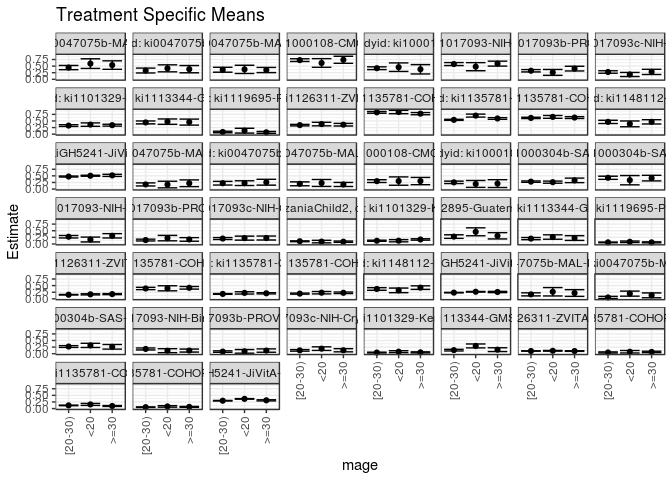

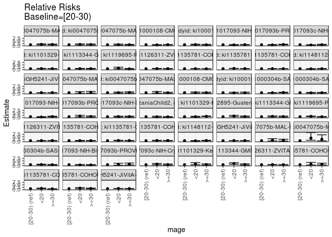

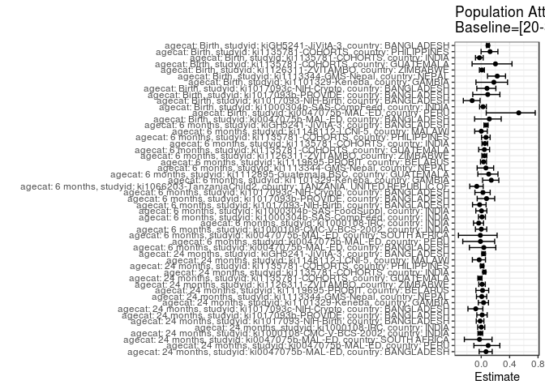

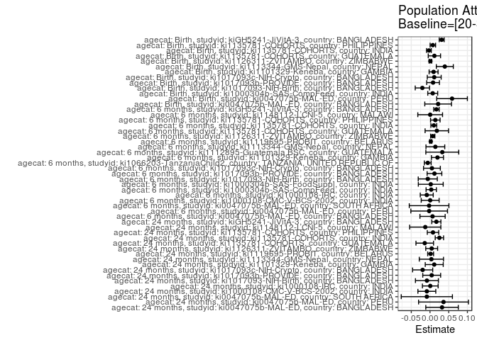

## Results Table

### Parameter: TSM

| agecat | studyid | country | intervention_level | baseline_level | estimate | ci_lower | ci_upper |
| --- | --- | --- | --- | --- | --- | --- | --- |
| Birth | ki0047075b-MAL-ED | BANGLADESH | [20-30) | NA | 0.1687500 | 0.1105909 | 0.2269091 |
| Birth | ki0047075b-MAL-ED | BANGLADESH | <20 | NA | 0.2666667 | 0.1080808 | 0.4252526 |
| Birth | ki0047075b-MAL-ED | BANGLADESH | >=30 | NA | 0.2195122 | 0.0925394 | 0.3464850 |
| Birth | ki0047075b-MAL-ED | PERU | [20-30) | NA | 0.0526316 | 0.0115533 | 0.0937099 |
| Birth | ki0047075b-MAL-ED | PERU | <20 | NA | 0.1969697 | 0.1008138 | 0.2931256 |
| Birth | ki0047075b-MAL-ED | PERU | >=30 | NA | 0.1320755 | 0.0407281 | 0.2234229 |
| Birth | ki1000304b-SAS-CompFeed | INDIA | [20-30) | NA | 0.2714729 | 0.2377571 | 0.3051888 |
| Birth | ki1000304b-SAS-CompFeed | INDIA | <20 | NA | 0.3142274 | 0.2352932 | 0.3931616 |
| Birth | ki1000304b-SAS-CompFeed | INDIA | >=30 | NA | 0.2611493 | 0.1746306 | 0.3476679 |
| Birth | ki1017093-NIH-Birth | BANGLADESH | [20-30) | NA | 0.1804878 | 0.1432301 | 0.2177455 |
| Birth | ki1017093-NIH-Birth | BANGLADESH | <20 | NA | 0.1142857 | 0.0396923 | 0.1888791 |
| Birth | ki1017093-NIH-Birth | BANGLADESH | >=30 | NA | 0.1190476 | 0.0624552 | 0.1756400 |
| Birth | ki1017093b-PROVIDE | BANGLADESH | [20-30) | NA | 0.0808625 | 0.0530956 | 0.1086295 |
| Birth | ki1017093b-PROVIDE | BANGLADESH | <20 | NA | 0.0895522 | 0.0211170 | 0.1579875 |
| Birth | ki1017093b-PROVIDE | BANGLADESH | >=30 | NA | 0.1188119 | 0.0556500 | 0.1819737 |
| Birth | ki1017093c-NIH-Crypto | BANGLADESH | [20-30) | NA | 0.1266731 | 0.0970352 | 0.1563110 |
| Birth | ki1017093c-NIH-Crypto | BANGLADESH | <20 | NA | 0.1915854 | 0.1238785 | 0.2592924 |
| Birth | ki1017093c-NIH-Crypto | BANGLADESH | >=30 | NA | 0.1309015 | 0.0705831 | 0.1912199 |
| Birth | ki1101329-Keneba | GAMBIA | [20-30) | NA | 0.0442190 | 0.0291388 | 0.0592992 |
| Birth | ki1101329-Keneba | GAMBIA | <20 | NA | 0.0773021 | 0.0415447 | 0.1130595 |
| Birth | ki1101329-Keneba | GAMBIA | >=30 | NA | 0.0508714 | 0.0322086 | 0.0695342 |
| Birth | ki1113344-GMS-Nepal | NEPAL | [20-30) | NA | 0.1356914 | 0.1037033 | 0.1676795 |
| Birth | ki1113344-GMS-Nepal | NEPAL | <20 | NA | 0.2940777 | 0.2194852 | 0.3686702 |
| Birth | ki1113344-GMS-Nepal | NEPAL | >=30 | NA | 0.1529152 | 0.0809711 | 0.2248593 |
| Birth | ki1126311-ZVITAMBO | ZIMBABWE | [20-30) | NA | 0.1021342 | 0.0959330 | 0.1083354 |
| Birth | ki1126311-ZVITAMBO | ZIMBABWE | <20 | NA | 0.1103079 | 0.0967399 | 0.1238759 |
| Birth | ki1126311-ZVITAMBO | ZIMBABWE | >=30 | NA | 0.1010610 | 0.0881326 | 0.1139894 |
| Birth | ki1135781-COHORTS | GUATEMALA | [20-30) | NA | 0.0469136 | 0.0263077 | 0.0675195 |
| Birth | ki1135781-COHORTS | GUATEMALA | <20 | NA | 0.0743802 | 0.0276007 | 0.1211596 |
| Birth | ki1135781-COHORTS | GUATEMALA | >=30 | NA | 0.0674847 | 0.0402373 | 0.0947320 |

[output cut: 123 more lines]

### Parameter: E(Y)

| agecat | studyid | country | intervention_level | baseline_level | estimate | ci_lower | ci_upper |
| --- | --- | --- | --- | --- | --- | --- | --- |
| Birth | ki0047075b-MAL-ED | BANGLADESH | NA | NA | 0.1904762 | 0.1397281 | 0.2412242 |
| Birth | ki0047075b-MAL-ED | PERU | NA | NA | 0.1115880 | 0.0710726 | 0.1521034 |
| Birth | ki1000304b-SAS-CompFeed | INDIA | NA | NA | 0.2787540 | 0.2475949 | 0.3099131 |
| Birth | ki1017093-NIH-Birth | BANGLADESH | NA | NA | 0.1600660 | 0.1308485 | 0.1892835 |
| Birth | ki1017093b-PROVIDE | BANGLADESH | NA | NA | 0.0890538 | 0.0649864 | 0.1131212 |
| Birth | ki1017093c-NIH-Crypto | BANGLADESH | NA | NA | 0.1379781 | 0.1129774 | 0.1629789 |
| Birth | ki1101329-Keneba | GAMBIA | NA | NA | 0.0537913 | 0.0425309 | 0.0650518 |
| Birth | ki1113344-GMS-Nepal | NEPAL | NA | NA | 0.1752874 | 0.1470202 | 0.2035545 |
| Birth | ki1126311-ZVITAMBO | ZIMBABWE | NA | NA | 0.1032165 | 0.0981467 | 0.1082863 |
| Birth | ki1135781-COHORTS | GUATEMALA | NA | NA | 0.0586854 | 0.0428942 | 0.0744767 |
| Birth | ki1135781-COHORTS | INDIA | NA | NA | 0.1183457 | 0.1091247 | 0.1275667 |
| Birth | ki1135781-COHORTS | PHILIPPINES | NA | NA | 0.0613115 | 0.0527962 | 0.0698268 |
| Birth | kiGH5241-JiVitA-3 | BANGLADESH | NA | NA | 0.3289521 | 0.3215868 | 0.3363173 |
| 6 months | ki0047075b-MAL-ED | BANGLADESH | NA | NA | 0.1825726 | 0.1336978 | 0.2314474 |
| 6 months | ki0047075b-MAL-ED | PERU | NA | NA | 0.2197802 | 0.1705687 | 0.2689917 |
| 6 months | ki0047075b-MAL-ED | SOUTH AFRICA | NA | NA | 0.1968504 | 0.1478551 | 0.2458457 |
| 6 months | ki1000108-CMC-V-BCS-2002 | INDIA | NA | NA | 0.3008130 | 0.2539566 | 0.3476694 |
| 6 months | ki1000108-IRC | INDIA | NA | NA | 0.2457002 | 0.2038248 | 0.2875757 |
| 6 months | ki1000304b-SAS-CompFeed | INDIA | NA | NA | 0.2844311 | 0.2666491 | 0.3022132 |
| 6 months | ki1000304b-SAS-FoodSuppl | INDIA | NA | NA | 0.4289474 | 0.3791199 | 0.4787748 |
| 6 months | ki1017093-NIH-Birth | BANGLADESH | NA | NA | 0.2672897 | 0.2297549 | 0.3048246 |
| 6 months | ki1017093b-PROVIDE | BANGLADESH | NA | NA | 0.1589404 | 0.1297581 | 0.1881227 |
| 6 months | ki1017093c-NIH-Crypto | BANGLADESH | NA | NA | 0.2097902 | 0.1799252 | 0.2396552 |
| 6 months | ki1066203-TanzaniaChild2 | TANZANIA, UNITED REPUBLIC OF | NA | NA | 0.0964215 | 0.0835208 | 0.1093221 |
| 6 months | ki1101329-Keneba | GAMBIA | NA | NA | 0.1408654 | 0.1259115 | 0.1558193 |
| 6 months | ki1112895-Guatemala BSC | GUATEMALA | NA | NA | 0.3115942 | 0.2568550 | 0.3663334 |
| 6 months | ki1113344-GMS-Nepal | NEPAL | NA | NA | 0.2163121 | 0.1823021 | 0.2503220 |
| 6 months | ki1119695-PROBIT | BELARUS | NA | NA | 0.0626864 | 0.0488489 | 0.0765238 |
| 6 months | ki1126311-ZVITAMBO | ZIMBABWE | NA | NA | 0.1627181 | 0.1549406 | 0.1704957 |
| 6 months | ki1135781-COHORTS | GUATEMALA | NA | NA | 0.4099896 | 0.3788775 | 0.4411017 |
| 6 months | ki1135781-COHORTS | INDIA | NA | NA | 0.1959625 | 0.1848518 | 0.2070732 |
| 6 months | ki1135781-COHORTS | PHILIPPINES | NA | NA | 0.2112260 | 0.1958496 | 0.2266024 |
| 6 months | ki1148112-LCNI-5 | MALAWI | NA | NA | 0.3736921 | 0.3370052 | 0.4103790 |
| 6 months | kiGH5241-JiVitA-3 | BANGLADESH | NA | NA | 0.2514133 | 0.2432880 | 0.2595385 |
| 24 months | ki0047075b-MAL-ED | BANGLADESH | NA | NA | 0.4764151 | 0.4090254 | 0.5438047 |
| 24 months | ki0047075b-MAL-ED | PERU | NA | NA | 0.3681592 | 0.3013164 | 0.4350020 |
| 24 months | ki0047075b-MAL-ED | SOUTH AFRICA | NA | NA | 0.3529412 | 0.2921001 | 0.4137823 |
| 24 months | ki1000108-CMC-V-BCS-2002 | INDIA | NA | NA | 0.7169811 | 0.6710815 | 0.7628807 |
| 24 months | ki1000108-IRC | INDIA | NA | NA | 0.4205379 | 0.3726382 | 0.4684376 |
| 24 months | ki1017093-NIH-Birth | BANGLADESH | NA | NA | 0.5690867 | 0.5220618 | 0.6161115 |
| 24 months | ki1017093b-PROVIDE | BANGLADESH | NA | NA | 0.3287197 | 0.2903909 | 0.3670485 |
| 24 months | ki1017093c-NIH-Crypto | BANGLADESH | NA | NA | 0.2568093 | 0.2190047 | 0.2946140 |
| 24 months | ki1101329-Keneba | GAMBIA | NA | NA | 0.3372229 | 0.3148351 | 0.3596107 |
| 24 months | ki1113344-GMS-Nepal | NEPAL | NA | NA | 0.4487705 | 0.4045970 | 0.4929440 |
| 24 months | ki1119695-PROBIT | BELARUS | NA | NA | 0.0852540 | 0.0554439 | 0.1150642 |
| 24 months | ki1126311-ZVITAMBO | ZIMBABWE | NA | NA | 0.3473748 | 0.3243098 | 0.3704399 |
| 24 months | ki1135781-COHORTS | GUATEMALA | NA | NA | 0.8120301 | 0.7885439 | 0.8355162 |
| 24 months | ki1135781-COHORTS | INDIA | NA | NA | 0.5674431 | 0.5514601 | 0.5834261 |
| 24 months | ki1135781-COHORTS | PHILIPPINES | NA | NA | 0.6229039 | 0.6036892 | 0.6421186 |
| 24 months | ki1148112-LCNI-5 | MALAWI | NA | NA | 0.4526316 | 0.4078220 | 0.4974412 |
| 24 months | kiGH5241-JiVitA-3 | BANGLADESH | NA | NA | 0.4912484 | 0.4781170 | 0.5043798 |

### Parameter: RR

| agecat | studyid | country | intervention_level | baseline_level | estimate | ci_lower | ci_upper |
| --- | --- | --- | --- | --- | --- | --- | --- |
| Birth | ki0047075b-MAL-ED | BANGLADESH | [20-30) | [20-30) | 1.0000000 | 1.0000000 | 1.0000000 |
| Birth | ki0047075b-MAL-ED | BANGLADESH | <20 | [20-30) | 1.5802469 | 0.7947195 | 3.1422159 |
| Birth | ki0047075b-MAL-ED | BANGLADESH | >=30 | [20-30) | 1.3008130 | 0.6634287 | 2.5505598 |
| Birth | ki0047075b-MAL-ED | PERU | [20-30) | [20-30) | 1.0000000 | 1.0000000 | 1.0000000 |
| Birth | ki0047075b-MAL-ED | PERU | <20 | [20-30) | 3.7424242 | 1.4905555 | 9.3963220 |
| Birth | ki0047075b-MAL-ED | PERU | >=30 | [20-30) | 2.5094340 | 0.8844567 | 7.1199176 |
| Birth | ki1000304b-SAS-CompFeed | INDIA | [20-30) | [20-30) | 1.0000000 | 1.0000000 | 1.0000000 |
| Birth | ki1000304b-SAS-CompFeed | INDIA | <20 | [20-30) | 1.1574908 | 0.8535169 | 1.5697226 |
| Birth | ki1000304b-SAS-CompFeed | INDIA | >=30 | [20-30) | 0.9619716 | 0.7191190 | 1.2868377 |
| Birth | ki1017093-NIH-Birth | BANGLADESH | [20-30) | [20-30) | 1.0000000 | 1.0000000 | 1.0000000 |
| Birth | ki1017093-NIH-Birth | BANGLADESH | <20 | [20-30) | 0.6332046 | 0.3193333 | 1.2555786 |
| Birth | ki1017093-NIH-Birth | BANGLADESH | >=30 | [20-30) | 0.6595882 | 0.3928211 | 1.1075183 |
| Birth | ki1017093b-PROVIDE | BANGLADESH | [20-30) | [20-30) | 1.0000000 | 1.0000000 | 1.0000000 |
| Birth | ki1017093b-PROVIDE | BANGLADESH | <20 | [20-30) | 1.1074627 | 0.4791575 | 2.5596459 |
| Birth | ki1017093b-PROVIDE | BANGLADESH | >=30 | [20-30) | 1.4693069 | 0.7802980 | 2.7667159 |
| Birth | ki1017093c-NIH-Crypto | BANGLADESH | [20-30) | [20-30) | 1.0000000 | 1.0000000 | 1.0000000 |
| Birth | ki1017093c-NIH-Crypto | BANGLADESH | <20 | [20-30) | 1.5124397 | 0.9899653 | 2.3106606 |
| Birth | ki1017093c-NIH-Crypto | BANGLADESH | >=30 | [20-30) | 1.0333805 | 0.6165181 | 1.7321068 |
| Birth | ki1101329-Keneba | GAMBIA | [20-30) | [20-30) | 1.0000000 | 1.0000000 | 1.0000000 |
| Birth | ki1101329-Keneba | GAMBIA | <20 | [20-30) | 1.7481635 | 0.9840706 | 3.1055452 |
| Birth | ki1101329-Keneba | GAMBIA | >=30 | [20-30) | 1.1504412 | 0.6972251 | 1.8982606 |
| Birth | ki1113344-GMS-Nepal | NEPAL | [20-30) | [20-30) | 1.0000000 | 1.0000000 | 1.0000000 |
| Birth | ki1113344-GMS-Nepal | NEPAL | <20 | [20-30) | 2.1672537 | 1.5328869 | 3.0641456 |
| Birth | ki1113344-GMS-Nepal | NEPAL | >=30 | [20-30) | 1.1269334 | 0.6659067 | 1.9071425 |
| Birth | ki1126311-ZVITAMBO | ZIMBABWE | [20-30) | [20-30) | 1.0000000 | 1.0000000 | 1.0000000 |
| Birth | ki1126311-ZVITAMBO | ZIMBABWE | <20 | [20-30) | 1.0800290 | 0.9416797 | 1.2387042 |
| Birth | ki1126311-ZVITAMBO | ZIMBABWE | >=30 | [20-30) | 0.9894928 | 0.8588608 | 1.1399937 |
| Birth | ki1135781-COHORTS | GUATEMALA | [20-30) | [20-30) | 1.0000000 | 1.0000000 | 1.0000000 |
| Birth | ki1135781-COHORTS | GUATEMALA | <20 | [20-30) | 1.5854719 | 0.7362135 | 3.4143916 |
| Birth | ki1135781-COHORTS | GUATEMALA | >=30 | [20-30) | 1.4384888 | 0.7921406 | 2.6122257 |

[output cut: 123 more lines]

### Parameter: PAR

| agecat | studyid | country | intervention_level | baseline_level | estimate | ci_lower | ci_upper |
| --- | --- | --- | --- | --- | --- | --- | --- |
| Birth | ki0047075b-MAL-ED | BANGLADESH | [20-30) | NA | 0.0217262 | -0.0139411 | 0.0573935 |
| Birth | ki0047075b-MAL-ED | PERU | [20-30) | NA | 0.0589564 | 0.0179966 | 0.0999162 |
| Birth | ki1000304b-SAS-CompFeed | INDIA | [20-30) | NA | 0.0072811 | -0.0059752 | 0.0205374 |
| Birth | ki1017093-NIH-Birth | BANGLADESH | [20-30) | NA | -0.0204218 | -0.0394864 | -0.0013572 |
| Birth | ki1017093b-PROVIDE | BANGLADESH | [20-30) | NA | 0.0081913 | -0.0088047 | 0.0251872 |
| Birth | ki1017093c-NIH-Crypto | BANGLADESH | [20-30) | NA | 0.0113050 | -0.0072397 | 0.0298497 |
| Birth | ki1101329-Keneba | GAMBIA | [20-30) | NA | 0.0095723 | -0.0023947 | 0.0215393 |
| Birth | ki1113344-GMS-Nepal | NEPAL | [20-30) | NA | 0.0395960 | 0.0168907 | 0.0623012 |
| Birth | ki1126311-ZVITAMBO | ZIMBABWE | [20-30) | NA | 0.0010823 | -0.0025176 | 0.0046822 |
| Birth | ki1135781-COHORTS | GUATEMALA | [20-30) | NA | 0.0117719 | -0.0046688 | 0.0282125 |
| Birth | ki1135781-COHORTS | INDIA | [20-30) | NA | -0.0029287 | -0.0093229 | 0.0034656 |
| Birth | ki1135781-COHORTS | PHILIPPINES | [20-30) | NA | 0.0076430 | 0.0003419 | 0.0149441 |
| Birth | kiGH5241-JiVitA-3 | BANGLADESH | [20-30) | NA | 0.0311834 | 0.0245608 | 0.0378059 |
| 6 months | ki0047075b-MAL-ED | BANGLADESH | [20-30) | NA | 0.0068150 | -0.0269196 | 0.0405497 |
| 6 months | ki0047075b-MAL-ED | PERU | [20-30) | NA | -0.0022416 | -0.0512483 | 0.0467651 |
| 6 months | ki0047075b-MAL-ED | SOUTH AFRICA | [20-30) | NA | -0.0024150 | -0.0553866 | 0.0505565 |
| 6 months | ki1000108-CMC-V-BCS-2002 | INDIA | [20-30) | NA | 0.0004717 | -0.0234227 | 0.0243661 |
| 6 months | ki1000108-IRC | INDIA | [20-30) | NA | -0.0086857 | -0.0260063 | 0.0086349 |
| 6 months | ki1000304b-SAS-CompFeed | INDIA | [20-30) | NA | 0.0033025 | -0.0104863 | 0.0170914 |
| 6 months | ki1000304b-SAS-FoodSuppl | INDIA | [20-30) | NA | 0.0020677 | -0.0311545 | 0.0352898 |
| 6 months | ki1017093-NIH-Birth | BANGLADESH | [20-30) | NA | -0.0059439 | -0.0314209 | 0.0195330 |
| 6 months | ki1017093b-PROVIDE | BANGLADESH | [20-30) | NA | 0.0119324 | -0.0076936 | 0.0315585 |
| 6 months | ki1017093c-NIH-Crypto | BANGLADESH | [20-30) | NA | 0.0051963 | -0.0172600 | 0.0276526 |
| 6 months | ki1066203-TanzaniaChild2 | TANZANIA, UNITED REPUBLIC OF | [20-30) | NA | -0.0060234 | -0.0151329 | 0.0030862 |
| 6 months | ki1101329-Keneba | GAMBIA | [20-30) | NA | 0.0199756 | 0.0039130 | 0.0360382 |
| 6 months | ki1112895-Guatemala BSC | GUATEMALA | [20-30) | NA | 0.0328635 | -0.0111479 | 0.0768750 |
| 6 months | ki1113344-GMS-Nepal | NEPAL | [20-30) | NA | 0.0143147 | -0.0107698 | 0.0393991 |
| 6 months | ki1119695-PROBIT | BELARUS | [20-30) | NA | 0.0020603 | -0.0007859 | 0.0049065 |
| 6 months | ki1126311-ZVITAMBO | ZIMBABWE | [20-30) | NA | 0.0073589 | 0.0017388 | 0.0129790 |
| 6 months | ki1135781-COHORTS | GUATEMALA | [20-30) | NA | 0.0182481 | -0.0131005 | 0.0495968 |
| 6 months | ki1135781-COHORTS | INDIA | [20-30) | NA | 0.0102152 | 0.0023861 | 0.0180443 |
| 6 months | ki1135781-COHORTS | PHILIPPINES | [20-30) | NA | 0.0142214 | 0.0014834 | 0.0269593 |
| 6 months | ki1148112-LCNI-5 | MALAWI | [20-30) | NA | 0.0004513 | -0.0326030 | 0.0335056 |
| 6 months | kiGH5241-JiVitA-3 | BANGLADESH | [20-30) | NA | 0.0172339 | 0.0099627 | 0.0245051 |
| 24 months | ki0047075b-MAL-ED | BANGLADESH | [20-30) | NA | 0.0321876 | -0.0112537 | 0.0756290 |
| 24 months | ki0047075b-MAL-ED | PERU | [20-30) | NA | 0.0361426 | -0.0304937 | 0.1027788 |
| 24 months | ki0047075b-MAL-ED | SOUTH AFRICA | [20-30) | NA | -0.0084758 | -0.0768769 | 0.0599252 |
| 24 months | ki1000108-CMC-V-BCS-2002 | INDIA | [20-30) | NA | -0.0084426 | -0.0323497 | 0.0154645 |
| 24 months | ki1000108-IRC | INDIA | [20-30) | NA | 0.0007128 | -0.0203193 | 0.0217449 |
| 24 months | ki1017093-NIH-Birth | BANGLADESH | [20-30) | NA | -0.0082289 | -0.0388863 | 0.0224284 |
| 24 months | ki1017093b-PROVIDE | BANGLADESH | [20-30) | NA | 0.0045364 | -0.0193968 | 0.0284697 |
| 24 months | ki1017093c-NIH-Crypto | BANGLADESH | [20-30) | NA | -0.0196635 | -0.0465325 | 0.0072054 |
| 24 months | ki1101329-Keneba | GAMBIA | [20-30) | NA | 0.0113369 | -0.0127149 | 0.0353886 |
| 24 months | ki1113344-GMS-Nepal | NEPAL | [20-30) | NA | 0.0037052 | -0.0286825 | 0.0360930 |
| 24 months | ki1119695-PROBIT | BELARUS | [20-30) | NA | 0.0016695 | -0.0061656 | 0.0095045 |
| 24 months | ki1126311-ZVITAMBO | ZIMBABWE | [20-30) | NA | 0.0045121 | -0.0113355 | 0.0203597 |
| 24 months | ki1135781-COHORTS | GUATEMALA | [20-30) | NA | -0.0140545 | -0.0375238 | 0.0094148 |
| 24 months | ki1135781-COHORTS | INDIA | [20-30) | NA | 0.0251006 | 0.0139115 | 0.0362896 |
| 24 months | ki1135781-COHORTS | PHILIPPINES | [20-30) | NA | 0.0079912 | -0.0072000 | 0.0231823 |
| 24 months | ki1148112-LCNI-5 | MALAWI | [20-30) | NA | -0.0126691 | -0.0543396 | 0.0290014 |
| 24 months | kiGH5241-JiVitA-3 | BANGLADESH | [20-30) | NA | 0.0169593 | 0.0048048 | 0.0291138 |

### Parameter: PAF

| agecat | studyid | country | intervention_level | baseline_level | estimate | ci_lower | ci_upper |
| --- | --- | --- | --- | --- | --- | --- | --- |
| Birth | ki0047075b-MAL-ED | BANGLADESH | [20-30) | NA | 0.1140625 | -0.0926693 | 0.2816809 |
| Birth | ki0047075b-MAL-ED | PERU | [20-30) | NA | 0.5283401 | 0.0707564 | 0.7605977 |
| Birth | ki1000304b-SAS-CompFeed | INDIA | [20-30) | NA | 0.0261200 | -0.0226732 | 0.0725853 |
| Birth | ki1017093-NIH-Birth | BANGLADESH | [20-30) | NA | -0.1275836 | -0.2517561 | -0.0157288 |
| Birth | ki1017093b-PROVIDE | BANGLADESH | [20-30) | NA | 0.0919811 | -0.1187609 | 0.2630255 |
| Birth | ki1017093c-NIH-Crypto | BANGLADESH | [20-30) | NA | 0.0819335 | -0.0620758 | 0.2064162 |
| Birth | ki1101329-Keneba | GAMBIA | [20-30) | NA | 0.1779524 | -0.0738855 | 0.3707315 |
| Birth | ki1113344-GMS-Nepal | NEPAL | [20-30) | NA | 0.2258917 | 0.0886490 | 0.3424666 |
| Birth | ki1126311-ZVITAMBO | ZIMBABWE | [20-30) | NA | 0.0104857 | -0.0250144 | 0.0447564 |
| Birth | ki1135781-COHORTS | GUATEMALA | [20-30) | NA | 0.2005926 | -0.1282348 | 0.4335823 |
| Birth | ki1135781-COHORTS | INDIA | [20-30) | NA | -0.0247466 | -0.0801949 | 0.0278554 |
| Birth | ki1135781-COHORTS | PHILIPPINES | [20-30) | NA | 0.1246586 | -0.0016277 | 0.2350225 |
| Birth | kiGH5241-JiVitA-3 | BANGLADESH | [20-30) | NA | 0.0947960 | 0.0743514 | 0.1147891 |
| 6 months | ki0047075b-MAL-ED | BANGLADESH | [20-30) | NA | 0.0373278 | -0.1661830 | 0.2053239 |
| 6 months | ki0047075b-MAL-ED | PERU | [20-30) | NA | -0.0101992 | -0.2597001 | 0.1898846 |
| 6 months | ki0047075b-MAL-ED | SOUTH AFRICA | [20-30) | NA | -0.0122684 | -0.3204120 | 0.2239639 |
| 6 months | ki1000108-CMC-V-BCS-2002 | INDIA | [20-30) | NA | 0.0015681 | -0.0811098 | 0.0779232 |
| 6 months | ki1000108-IRC | INDIA | [20-30) | NA | -0.0353509 | -0.1082112 | 0.0327192 |
| 6 months | ki1000304b-SAS-CompFeed | INDIA | [20-30) | NA | 0.0116111 | -0.0382838 | 0.0591082 |
| 6 months | ki1000304b-SAS-FoodSuppl | INDIA | [20-30) | NA | 0.0048203 | -0.0757216 | 0.0793319 |
| 6 months | ki1017093-NIH-Birth | BANGLADESH | [20-30) | NA | -0.0222378 | -0.1220993 | 0.0687364 |
| 6 months | ki1017093b-PROVIDE | BANGLADESH | [20-30) | NA | 0.0750749 | -0.0563949 | 0.1901831 |
| 6 months | ki1017093c-NIH-Crypto | BANGLADESH | [20-30) | NA | 0.0247690 | -0.0883198 | 0.1261066 |
| 6 months | ki1066203-TanzaniaChild2 | TANZANIA, UNITED REPUBLIC OF | [20-30) | NA | -0.0624690 | -0.1609437 | 0.0276528 |
| 6 months | ki1101329-Keneba | GAMBIA | [20-30) | NA | 0.1418063 | 0.0203714 | 0.2481880 |
| 6 months | ki1112895-Guatemala BSC | GUATEMALA | [20-30) | NA | 0.1054690 | -0.0472237 | 0.2358980 |
| 6 months | ki1113344-GMS-Nepal | NEPAL | [20-30) | NA | 0.0661760 | -0.0570642 | 0.1750480 |
| 6 months | ki1119695-PROBIT | BELARUS | [20-30) | NA | 0.0328666 | -0.0102330 | 0.0741275 |
| 6 months | ki1126311-ZVITAMBO | ZIMBABWE | [20-30) | NA | 0.0452247 | 0.0100785 | 0.0791231 |
| 6 months | ki1135781-COHORTS | GUATEMALA | [20-30) | NA | 0.0445087 | -0.0351019 | 0.1179965 |
| 6 months | ki1135781-COHORTS | INDIA | [20-30) | NA | 0.0521284 | 0.0113835 | 0.0911941 |
| 6 months | ki1135781-COHORTS | PHILIPPINES | [20-30) | NA | 0.0673277 | 0.0050815 | 0.1256795 |
| 6 months | ki1148112-LCNI-5 | MALAWI | [20-30) | NA | 0.0012076 | -0.0912799 | 0.0858567 |
| 6 months | kiGH5241-JiVitA-3 | BANGLADESH | [20-30) | NA | 0.0685480 | 0.0391781 | 0.0970201 |
| 24 months | ki0047075b-MAL-ED | BANGLADESH | [20-30) | NA | 0.0675622 | -0.0284638 | 0.1546223 |
| 24 months | ki0047075b-MAL-ED | PERU | [20-30) | NA | 0.0981711 | -0.1026450 | 0.2624142 |
| 24 months | ki0047075b-MAL-ED | SOUTH AFRICA | [20-30) | NA | -0.0240149 | -0.2373465 | 0.1525361 |
| 24 months | ki1000108-CMC-V-BCS-2002 | INDIA | [20-30) | NA | -0.0117752 | -0.0457112 | 0.0210595 |
| 24 months | ki1000108-IRC | INDIA | [20-30) | NA | 0.0016950 | -0.0495915 | 0.0504755 |
| 24 months | ki1017093-NIH-Birth | BANGLADESH | [20-30) | NA | -0.0144598 | -0.0697993 | 0.0380169 |
| 24 months | ki1017093b-PROVIDE | BANGLADESH | [20-30) | NA | 0.0138003 | -0.0617593 | 0.0839827 |
| 24 months | ki1017093c-NIH-Crypto | BANGLADESH | [20-30) | NA | -0.0765687 | -0.1866817 | 0.0233269 |
| 24 months | ki1101329-Keneba | GAMBIA | [20-30) | NA | 0.0336183 | -0.0404387 | 0.1024040 |
| 24 months | ki1113344-GMS-Nepal | NEPAL | [20-30) | NA | 0.0082564 | -0.0666090 | 0.0778670 |
| 24 months | ki1119695-PROBIT | BELARUS | [20-30) | NA | 0.0195822 | -0.0742974 | 0.1052578 |
| 24 months | ki1126311-ZVITAMBO | ZIMBABWE | [20-30) | NA | 0.0129892 | -0.0337122 | 0.0575808 |
| 24 months | ki1135781-COHORTS | GUATEMALA | [20-30) | NA | -0.0173079 | -0.0466608 | 0.0112219 |
| 24 months | ki1135781-COHORTS | INDIA | [20-30) | NA | 0.0442345 | 0.0242520 | 0.0638078 |
| 24 months | ki1135781-COHORTS | PHILIPPINES | [20-30) | NA | 0.0128289 | -0.0118769 | 0.0369314 |
| 24 months | ki1148112-LCNI-5 | MALAWI | [20-30) | NA | -0.0279899 | -0.1243355 | 0.0600998 |
| 24 months | kiGH5241-JiVitA-3 | BANGLADESH | [20-30) | NA | 0.0345229 | 0.0094539 | 0.0589574 |